# EU Subsidies/ No EU Subsidies

## History of EU Subsidies

When the European UNION was founded, the six founding countries agreed on a common agricultural policy (CAP). In 1962, the first agricultural subsidies were introduced, reaching producers in the form of intervention prices or export refunds. Since 1992, price supports have been gradually transformed into direct payments and disbursed in a manner decoupled from the crops Garzon (2006).

## Current Situation

The current period is overshadowed by numerous major crises at the international level. Agriculture is also affected by this. Currently, the CAP is being fundamentally reformed. The aim of the new CAP is to make agriculture more sustainable and climate-friendly. It should contribute to the set environmental and climate goals of the European Union. Small farms are also to be strengthened. Furthermore, the EU member states should be given more flexibility to adapt their domestic agricultural policies to local conditions. To this end, new decisions on direct payments will come into force as of January 2023 Dı́az et al. (2021).

### Change of the Subsidy Payment

To achieve the new goals, there will be a change in the payment of EU subsidies. Until now, only the requirements on the fertilizer regulation in Germany had to be met to receive subsidies. Environmental requirements and thus agronomic measures were not linked to the payment of subsidies. From 2023, the “basic premium” is expected to fall from the current €170/ha to around €150/ha. Furthermore, from then on, conditions must be met for the basic premium to be paid out Bockholt (2022); Stefanie Awater-Esper (2022).

- In the future, 4% of the arable land must be shut down
- 3 m border strips to water bodies because of water protection/
- no bare soil in winter / conservation tillage
- crop rotation

### Principle of Conditionality

In the new CAP, the principle of “conditionality” is planned. TIt states that, in the future, EU subsidies will only be paid, if the conditions are fulfilled. These conditions can severely restrict the farmers in their agronomic possibilities and can have a strong impact on the success of the farms Dı́az et al. (2021).

## Uncertainties

With the reduction of subsidies combined with new costly regulations, the question arose whether there are still advantages to using subsidies. To answer this question, many factors, often unpredictable, must be considered. The production conditions change very quickly. Prices for fertilizer, machinery, seeds, crop protection and fuel are currently subject to extreme fluctuations. These factors can be affected by rapid changes such as an economic crisis or other factors, for example, COVID-19. Likewise, the yield can change quickly due to a changing climate and therefore create an unstable yield level.  
As a result, the prices of the products are exposed to significant price fluctuations and are therefore unstable. Depending on the uncertainties described, mandatory measures will have to be implemented in the future in order to receive subsidies. These may have different effects on the success of the individual farms.

## Modulation

The points below outline a scenario in which the farmer chooses to receive the base subsidies and the subsidies paid for the maximum field size. In the flowchart, the selected subsidies are represented by the fields “basic_subsidies” and “small_fields_subsidies”, highlighted in gray. To receive both subsidies, the costs arise according to the principle of conditionality. These costs are represented additively by the fields “basic_subsidies_costs” and "costs_field_area_<_5_ha" colored in pink. The individual costs for the respective subsidy through conditions in the form of arable restrictions are shown by the orange fields.

For the basic subsidies, indirect costs resulting from the shutdown of arable land (costs_4%_shutdown), costs for careful and conservative soil cultivation (costs_consevation_tillage) and costs, resulting from measures for water protection.

In addition to the costs incurred by the type of subsidy requested, there are other costs to be considered. On the one hand, many farmers make use of an advisory service offered by the Chamber of Agriculture. Through this service, farmers are provided with advice and assistance in completing the applications. Another important consideration is the work and time commitment that farmers must dedicate in order to apply for subsidies. This results in additional costs that are directly related to the request for funding. These are presented by the fields “costs_consulting” and “costs_own_effort”.

**Flowchart 1:**

[interactive chart not shown]

Furthermore, general production costs are incurred. These also have an impact on operating profit. These extend the flow chart by the heading costs. The general production costs are shown with red fields. In summary, it can be noted that the production costs and the subsidies, affect the income. The subsidies cause costs by the principle of the conditionality first, before they can generate profit for it later also. Finally, the yield and the current grain market price must be included in the overall calculation. This is shown via the fields “market_price” and “yield” in flowchart 2.

**Flowchart 2:**

[interactive chart not shown]

## Input Data

The input data that are passed to the model function are shown in this table. However, the table shown here is only an excerpt. The column of the variable description is not displayed and only the first 6 rows are presented on the graph. The complete input table can be found in the git repository, which you can find [here](https://github.com/PhilippAusgust/EU_Subsidies).

### Data Sources

In order to obtain meaningful data for the input table, extensive research was conducted in this thesis. The current production costs were taken into account the website of the [Landwirtschaftskammer Schleswig-Hollstein](https://www.lksh.de/fileadmin/PDFs/Landwirtschaft/Markt/Kalkulationsdaten_Pflanzenproduktion_Wirtschaftsjahr_2018_20019.pdf) and the [Landwirtschaftskammer Nordrhein-Westfahlen](https://www.landwirtschaftskammer.de/foerderung/hinweise/agrarreform-2023.htm). Current prices for wheat, seeds and fertilizers were taken from the website [boerse-online.eu](https://www.boerse-online.de/rohstoffe/weizenpreis). In addition, several active farmers were interviewed. The interview results showed that revealed that each farmer has a different attitude towards subsidies. For some farmers, the threshold to fulfill the conditions to receive EU subsidies is relatively low while other farmers already face difficulties when filling out the relevant applications. To conclude, most farmers indicate that they will apply for the subsidies, even if it requires a lot of effort.

Input Table

| label | variable | distribution | lower | median | upper |
| --- | --- | --- | --- | --- | --- |
| time_horizon | n_years | const | 6.00 | NA | 6.00 |
| coeff. Variation | var_CV | posnorm | 0.08 | NA | 0.12 |
| discount rate | discount_rate | posnorm | 1.00 | NA | 5.00 |
| size_of_farm_[ha] | farm_size | const | 100.00 | NA | 100.00 |
| wheat_price_[€/dt] | price_wheat | posnorm | 15.50 | NA | 33.50 |
| wheat_yield_[dt/ha] | yield_wheat | posnorm | 50.00 | NA | 110.00 |

## Model Function

The model function is run twice. Once the receipt of subsidies is simulated and the expected profit is calculated under the premise that subsidies are paid and the necessary cuts and their costs are accepted. In the second variant, only the profit to be expected if no subsidies are paid is calculated. It should be noted that in this case there is no costs for subsidies. The exact execution of the model function can be found in the comments in the code.

### Build Function

```r
subsidies_decision_function <- function(x, varnames){

  # define variables with constant distribution

  farming_area_               <- rep(farm_size, n_years)
  eu_subsidies_basic          <- rep(eu_subsidies, n_years)
  eu_subsidies_small_fields   <- rep(small_fields, n_years)

  # define each variable with variation over the period of 6 years

  # income factors
  wheat_price     <- vv(price_wheat, var_CV, n_years)
  wheat_yield     <- vv(yield_wheat, var_CV, n_years)

  # general cost per ha
  costs_fer_seeds <- vv(seeding_fertilizer_costs,var_CV, n_years)
  costs_pest      <- vv(costs_pesticides,var_CV, n_years)
  costs_machy     <- vv(costs_machinery, var_CV, n_years)
  costs_insur     <- vv(hail_insurance, var_CV, n_years)

  # costs to get subsidies

  costs_consult               <- vv(cunsult_costs,var_CV,n_years)
  costs_shut_down             <- vv(costs_shutdown,var_CV,n_years)
  costs_conversation          <- vv(costs_cns_tillage, var_CV,n_years)
  costs_realize_small_fields  <- vv(more_cultivation_costs,var_CV, n_years)
  costs_own_effort            <- vv(own_efforts_costs,var_CV, n_years)
  costs_water_protec          <- vv(costs_water_protection,var_CV, n_years)
  costs_cultivation           <- vv(more_cultivation_costs,var_CV,n_years)

  # define arrays for the final result of Net Present Value

  net_subsidies <- rep(0, n_years)
  net_no_subsidies <- rep(0, n_years)



  # Preliminary calculation of the value of base EU subsidies and subsidies for
  # limiting each arable area in the farm to a maximum of 5 ha.


  basic_subsidies_small_fields_subsidies <- (farming_area_*eu_subsidies_basic
                                             +farming_area_*eu_subsidies_small_fields)

  # calculate risk in case the application for EU subsidies is completed
  # and processed but not finally submitted

  planned_to_get_subsidies_but_not_realized <- chance_event(risk_, 1, 0, n = 1)

  # At this point the case distinction begins Decision for or against subsidies

  for (decison_get_eu_subsidies in c(FALSE,TRUE)){

  # get eu subsidies

    if (decison_get_eu_subsidies){

      get_eu_subsidies <- TRUE
      application_costs <- TRUE

    }

    # get no eu subsidies

    else{

      get_eu_subsidies <- FALSE
      application_costs <- FALSE

    }

    # if the application is made and not submitted application costs are generated
    if (planned_to_get_subsidies_but_not_realized){

      get_eu_subsidies <- FALSE

    }
    # create an array for the consulting costs incurred annually
    cost_application <- rep(0, n_years)

    # calculation of annual consulting and application costs
    if (application_costs){
      cost_application <- (costs_consult+costs_own_effort)*farming_area_
    }

    # create array for annual consulting and application costs
    # create array for the annual brutto income from the subsidies
    annual_costs_subsidies <- rep(0,n_years)
    benefits_eu_subsidies  <- rep(0,n_years)


    if (get_eu_subsidies){

      # costs incurred for the application
      annual_costs_subsidies <- cost_application

      # subsidies potentially paid out by the application
      benefits_eu_subsidies  <- basic_subsidies_small_fields_subsidies
    }

      # array for arable costs incurred due to requirements for receiving EU subsidies.
    opportunity_costs_subsedies <- rep(0, n_years)

    if(get_eu_subsidies){
      # calculate arable costs incurred due to requirements for receiving EU subsidies.
      opportunity_costs_subsedies <- ((costs_shut_down+costs_conversation+costs_realize_small_fields
                                       +costs_water_protec+costs_cultivation)*farming_area_)

    }




    # final profit calculation with subsidies
    if(get_eu_subsidies){

      total_benefits <-  benefits_eu_subsidies + farming_area_*(wheat_price*wheat_yield)
      net_subsidies <-  (total_benefits - farming_area_*(costs_fer_seeds +costs_pest+costs_machy +costs_insur)
                         -opportunity_costs_subsedies)

    }

    else{
    # final profit calculation without subsidies
      net_no_subsidies <-  (farming_area_*(wheat_price*wheat_yield)
                                          -farming_area_*(costs_fer_seeds +costs_pest+costs_machy +costs_insur))


    }

  }

    # End of for loop

    # Include inflation

  NPV_subsidies<-
    discount(net_subsidies, discount_rate, calculate_NPV = TRUE)

  NPV_no_subsidies <-
    discount(net_no_subsidies, discount_rate, calculate_NPV = TRUE)

  return(list(
    NPV_subsidies = NPV_subsidies,
    NPV_no_subsidies = NPV_no_subsidies,
    NPV_subsidies_do = NPV_subsidies - NPV_no_subsidies,
    Cashflow_decision_do = net_subsidies - net_no_subsidies
  ))
 }
```

## Monte Carlo Simulation

After the model function has been created, it is passed to the function “mCSimulation” from the decision Support Package. Furthermore, the input table is transferred. Note that in this case the input table is a csv file and the semicolon is used as a separator. This must be adapted in the estimate_decison_read_csv function. The simulation is run 1000 times.

```r
mcSimulation_results <- decisionSupport::mcSimulation(
  estimate = decisionSupport::estimate_read_csv("Input_new.csv", sep=";"),
  model_function = subsidies_decision_function,
  numberOfModelRuns = 1e3,
  functionSyntax = "plainNames"
)
```

## Result

### Outcome Distribution

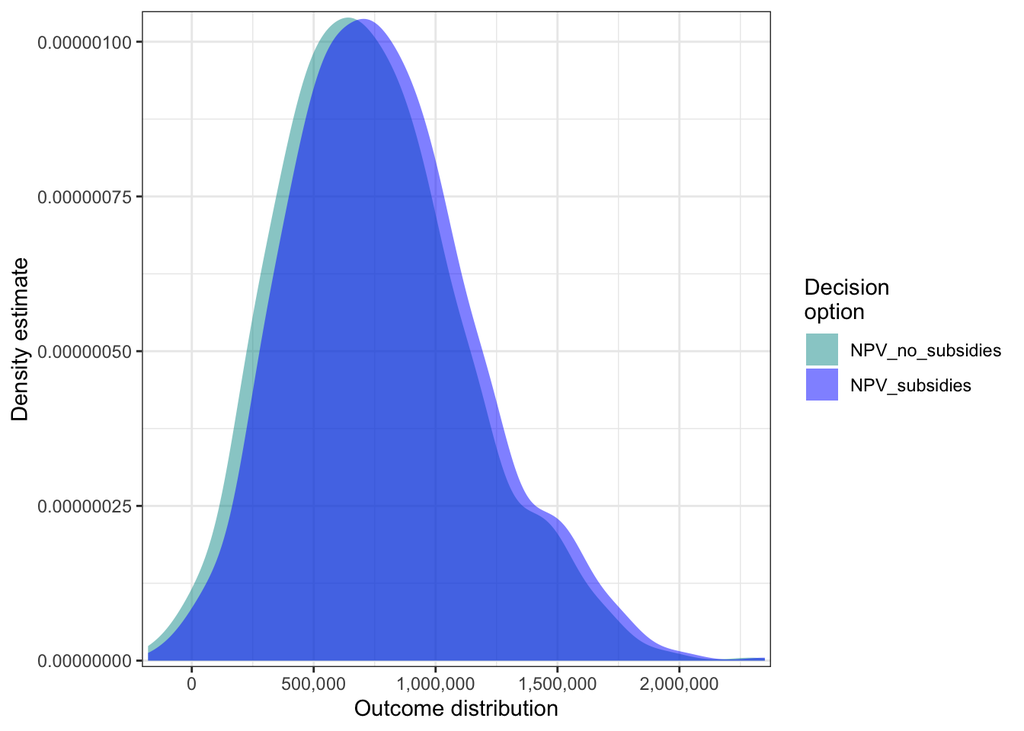

**Fig. 1** Income comparison over six years with and without subsidies

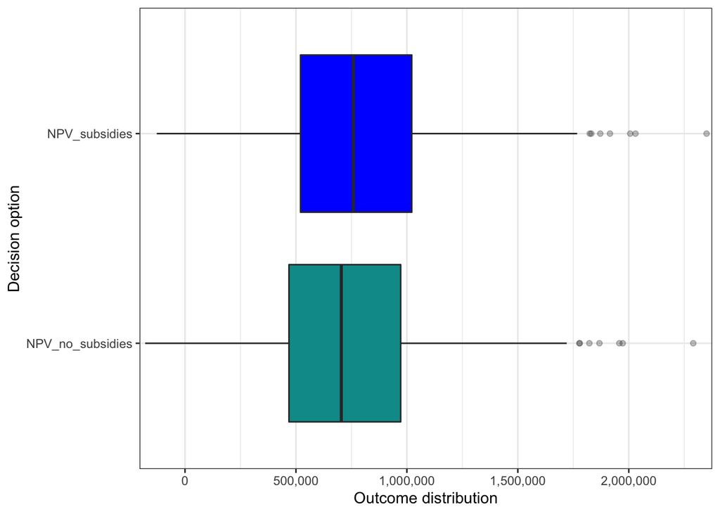

**Fig. 2** Income comparison over six years with and without subsidies boxplot

Figures 1 and 2 show the hypothetical farm yields of a 100 ha arable farm producing only wheat. As mentioned above, only the “basic subsidies” and the subsidies for a maximum area of five hectares are considered in this example.Figure 1 and 2 show the same facts. Only Figure 2 shows this via a boxplot. The individual probability of hitting one of the 1000 simulated farm profits is not indicated in Figure 2. It can be seen in both figures that the operating profit is higher with subsidies.

### Net Present Value (NPV)

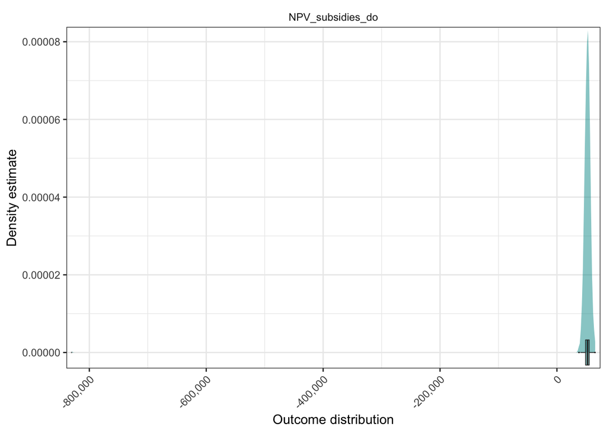

**Fig.3** NPV of Subsidies

The NPV returns the net benefit of the EU subsidies simulated here. This is consistently positive in most cases. However, there are exceptions in which a loss occurs when the decision is made in favour of subsidies. The results of this paper don’t show a consistency of this exceptions. The graphs and results generated in the Markdown html file differ and sometimes vary widely. Over 99 percent of simulated npv’s of EU subsidies result in an average profit of 55000 euros.

### Cash flow each year

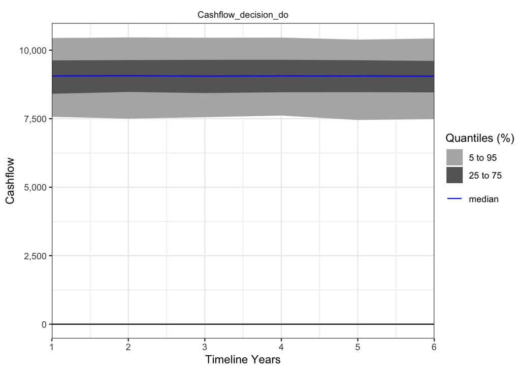

**Fig.4** Cashflow each year

Looking at the cash flow on Figure 4, it shows that if the decision is made in favor of EU subsidies, annual additional revenues of approx. 7000 - 10000 euros can be expected. The fluctuation range is relatively small.

### Variable Importance in Projection (VIP)

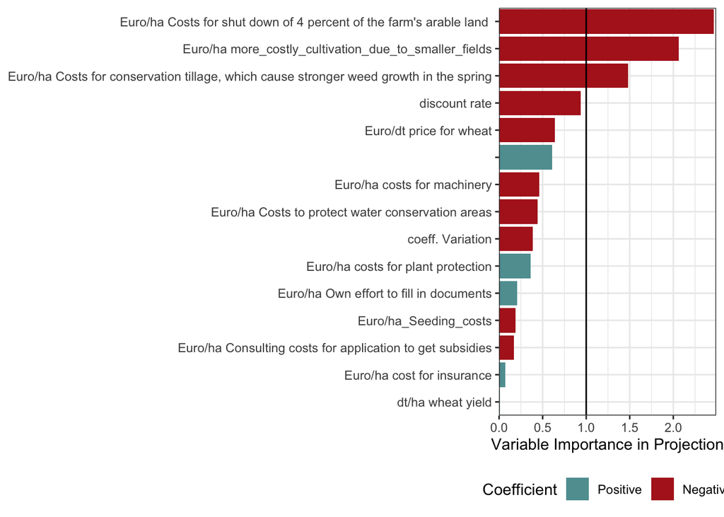

**Fig. 5** VIP

Figure 5 shows the VIP on the abscissa and the labels of the variables from the input table on the ordinate. The VIP indicates either a positive or a negative correlation. The highest VIP is seen when looking at the first label caused by the label “Euro/ha Costs for shut down of 4 percent of the farm´s arable land”. The color of the bar is red. Consequently, the higher the costs of setting aside 4% of farmland, the more likely people will choose not to receive subsidies. If a label has a green background, this means that the higher the costs caused by this label, the more likely it is that EU subsidies will be chosen.

## Value of Information (VoI) / Expected Value of Perfect Information (EVPI)

```r
mcSimulation_table <- data.frame(mcSimulation_results$x, mcSimulation_results$y[1:3])
evpi <- multi_EVPI(mc = mcSimulation_table, first_out_var = "NPV_subsidies")
```

```
## [1] "Processing 3 output variables. This can take some time."
## [1] "Output variable 1 (NPV_subsidies) completed."
## [1] "Output variable 2 (NPV_no_subsidies) completed."
## [1] "Output variable 3 (NPV_subsidies_do) completed."
```

Finally, it should be considered what benefit the information from the simulation provides. Decisions are often ambiguous. It is often possible to make a decision that gives you an advantage once, but creates a disadvantage the next time under only minimally different conditions. In these situations, it can help to identify the influencing variables that have a particularly strong impact on the decision and re-examine the initial decision process and alternate it. These variables have the highest value for a decision, and further research should be conducted on these influencing variables. In this example, it can be assumed in advance that there is an advantage in opting for EU subsidies.  
Therefore, there is no need to conduct further research on the most important influencing variables and no further expenses are incurred. The concept described here can also be calculated the EVPI. The EVPI represents the value that should be applied to obtain information that is optimal to judge whether to decide for or against subsidies Eike Luedeling (2022). In this case it is obvious that in any case the subsidies should be applied for. Therefore, an extensive information research is not necessary.

```r
plot_evpi(evpi, decision_vars = "NPV_subsidies_do")
```

[output not shown]

## References

Bockholt, Karl. 2022. “Agrarreform Ab 2023 Leicht Erklärt: Diese Begriffe Müssen Sie Kennen.” 2022. https://www.agrarheute.com/pflanze/getreide/agrarreform-ab-2023-leicht-erklaert-diese-begriffe-muessen-kennen-589408.

Dı́az, Mario, Elena D Concepción, Manuel B Morales, Juan Carlos Alonso, Francisco M Azcárate, Ignacio Bartomeus, Gérard Bota, et al. 2021. “Environmental Objectives of Spanish Agriculture: Scientific Guidelines for Their Effective Implementation Under the Common Agricultural Policy 2023-2030.” *Ardeola* 68 (2): 445–60.

Eike Luedeling, Katja Schiffers, Lutz Goehring. 2022. *DecisionSupport: Quantitative Support of Decision Making Under Uncertainty*. https://cran.r-project.org/web/packages/decisionSupport/index.html.

Garzon, Isabelle. 2006. *Reforming the Common Agricultural Policy: History of a Paradigm Change*. 1nd ed. Hampshire/New York: Palgrave Macmillan.

Stefanie Awater-Esper, Alfons Deter. 2022. “Agrarreform (Gap).” 2022. https://www.topagrar.com/themen/agrarreform-10108473.html.